# Introduzione a R

Autore/Autrice

Affiliazione

Ottavia M. Epifania ottavia.epifania@unitn.it

Università di Trento

# Introduzione

Prima di iniziare: Scaricate la cartella compressa data dentro cui si trovano tutti i dataset che sono usati in questo file.

`R` è un software open source per il calcolo statistico, la grafica e molto altro

## Installazione

> È necessario installare `R` (disponibile https://cran.r-project.org/bin/windows/base/)

`RStudio` è l’IDE perfetto per `R` $\rightarrow$consente un utilizzo di `R` migliore e più semplice

> `RStudio` si può installare dopo aver installato `R` (disponibile https://posit.co/download/rstudio-desktop/)

`R` funziona su Windows, MacOs, Unix

## RStudio IDE

La schermata di RStudio è suddivisa in 4 pannelli:

- Alto sx: è l’area dedicata agli script di codice
- Alto dx: l’area dove è possibile vedere quello che è presente all’interno dell’ambiente di R (i.e., tutti gli oggetti, le variabili, i dataframe che sono stati caricati/creati per le analisi)
- Basso sx: la console di R, dove vengono mostrati gli output delle operazioni e i codici eseguiti
- basso dx: l’area dei grafici

[figure not shown]

### Console

I comandi nella console vengono eseguiti ma il codice non viene salvato e scompare sequenzialmente.

Possono essere recuperati utilizzando la freccia verso l’alto.

Per eseguire qualsiasi comando nella console $\rightarrow$ Invio (o `Enter`)

L’output appare immediatamente nella console.

### Script

Si possono salvare gli script con tutte e righe di codice che servono per le analisi

Per far “correre” qualsiasi comando nello script $\rightarrow$ Ctrl + Invio (or `ctrl + Enter` or `cmd + Enter`) oppure utilizza semplicemente il pulsante “Run” in cima allo script.

L’output appare nella console.

Si possono inserire commenti (i.e., righe di codice che non vengono eseguite) inserendo `#` $\rightarrow$ tutto il testo dopo `#` non viene eseguito

Per fare lo switch alla console $\rightarrow$ `ctrl + 2`

Per fare lo switch allo script $\rightarrow$ `ctr + 1`

# Working directories

Bisogna conoscere le working directories (da qui in avanti indicate come `wd`), ovvero le cartelle dove si lavor, dove si salvano i dati ecc.

```r
getwd() # per sapere in quale wd si sta lavorando

dir() # lista degli oggetti all'interno della wd
```

Per cambiare la wd:

```r
setwd("C:/Users/huawei/OneDrive/Documenti/GitHub/RcouRse")
```

# Basics

## Calcolat`R`ice

```r
3 + 2   # più
3 - 2   # meno
3 * 2   # per
3 / 2   # diviso
sqrt(4) # radice quadrata
log(3)  # logaritmo naturale
exp(3)  # esponenziale
```

Parentesi e simili:

> `()` `[]` `{}` `""` `:` `;` `,`

L’uso delle parantesi funziona come se si stesse scrivendo un’equazione:

```r
(3 * 2)/ sqrt(25 + 4) # Look at me!
```

`R` ignora tutto quello dopo # (è un commento)

## Assign

I risultati delle operazioni possono essere “memorizzati” in oggetti (variabili, in senso informatico) con nomi specifici definiti dagli utenti

Per assegnare un valore a un oggetto, si possono utilizzare due operatori:

1. `x = exp(2^2)`
2. `X <- log(2^2)`

Gli elementi a destra del simbolo vengono assegnati all’oggetto a sinistra

Attenzione! `R` e case sensitive: `x` e `X` sono due oggetti diversi!!!

## Nomi delle variabili

[figure not shown]

Nomi di variabili validi sono lettere, numeri, punti, underscore (e.g., `variable_name`)

I nomi delle variabili non possono iniziare con numeri

L’idea per i nomi delle variabili è di dare indicazione di cosa contengono senza stare a scrivere divine commedie, ad esempio

Buoni nomi per le variabili:

- `mean_rt`
- `sum_age`
- `prop_item`

Pessimi nomi per variabili:

- `x`
- `y`
- `ciccio`

# Chiedere aiuto

`R` community is the best feature of `R`

Basta copiare & incollare qualsiasi messaggio di errore o avviso in Google o chiedere a Google “come fare **[qualcosa]** in R”.

Chiedete a `R` di aiutarvi! Basta scrivere `?` nella console seguito dal nome della funzione che si vuole conoscere:

```
?mean()
```

Mostra la help page della funzione `mean()`

# Ordine, ordine e ancora ordine

## R projects for the win

Gestire i directory di lavoro è un vero e proprio incubo. Per evitare di doverle gestire, si possono usare i porgetti di `R`

Un progetto R crea automaticamente una sorta di isola sul vostro pc con le sue sottoisole (che sono le sottocartelle che create voi)

Sono davvero comodi almeno per due motivi:

1. Permettono di avere diverse istanze di R aperte allo stesso tempo $\rightarrow$ Potete lavorare a progetti diversi contemporaneamente
2. Tutti i file sono sempre a disposizione, senza preoccuparsi delle wd

## Creare un nuovo `R` project

File $\rightarrow$ New project e scegliete quello che fa al caso vostro (a meno che non abbiate già inizializzato un directory per il tuo progetto, selezionate una nuova directory):

- `R` project “basic”
- `R` package
- `Shiny` project

e tanto altro

## Creare un nuovo R project

File $\rightarrow$ New project:

[figure not shown]

### Selezionare il tipo di progetto

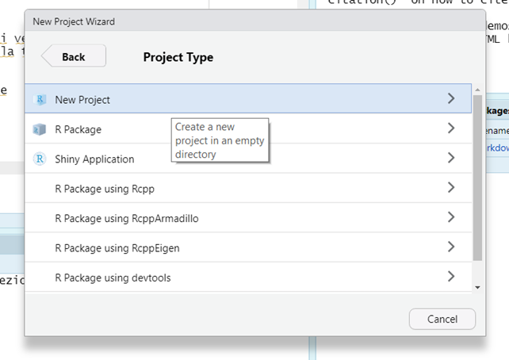

### Assegnargli una directory e dargli un nome

[figure not shown]

## Buttare via la spazzatura

L’ambiente R dovrebbe essere sempre ordinato

Per pulirlo:

```r
ls() # lista tutti gli oggetti nell'ambiente
rm(A) # rimuove l'oggetto A dalla directory
rm(list=ls()) # rimuove tutto dall'ambiente
```

## Salvare l’ambiente

Per salvare tutti i risultati delle analisi in formato ambiente di R:

```r
save.image("my-computations.RData")
```

Per ricaricare l’ambiente in R:

```r
load("my-computations.RData")
```

**Attenzione!**

I codici di prima, dove viene salvato e ricaricato l’ambiente, presuppone che l’ambiente di R venga salvato nella stessa wd dove è presente lo script

## Quando salvare l’ambiente?

I calcoli sono lenti e hai bisogno che siano sempre e facilmente accessibili

La pratica migliore è salvare lo script e documentarlo in un file `RMarkdown` $\rightarrow$ Riproducibilità!

## Your turn!

- Crea un progetto R per questo corso nella tua cartella “documenti” (scegli un nome carino :)
- Crea un nuovo script R (`shift + ctrl + n`)
- Calcolatrice utilizzando lo script:
  - $\sqrt{15} \times 14 - \frac{22}{4}$ [48.72177]
  - $\frac{\sqrt{7-\pi}}{3 \times (45-34)}$ [0.05952372]
- Salva lo script
- Assegna i risultati del primo calcolo a una variabile chiamata `my_results`

**See solution**

```r
# Calculator
sqrt(15) *14 - 22/4
```

```
[1] 48.72177
```

```r
# Calculator
sqrt(7 - pi)/(3*(45 -34))
```

```
[1] 0.05952372
```

```r
# assign
my_results = sqrt(15) *14 - 22/4
```

# Strutture in `R`

## Funzioni e loro argomenti

Quasi tutto si fa attraverso le funzioni, composte da:

- Un nome: `mean`
- un paio di parentesi: `()`
- degli argomenti: `na.rm = TRUE`

```r
mean(1:5, trim = 0, na.rm = TRUE)
```

```
[1] 3
```

Gli argomenti possono essere impostati con valori predefiniti; la funzione di ogni argomento è spiegata esaustivamente nell’help della funzione stessa, e.g., `?mean()`

Gli argomenti possono essere specificati:

- senza un nome (seguendo il loro ordine di default)
- con il loro nome (in qualsiasi ordine) $\rightarrow$ *keyword matching*

```r
mean(x, trim = 0.3, na.rm = TRUE)
```

Alcune funzioni funzionano anche senza argomenti:

```
ls(), dir(), getwd()
```

Per vedere il codice di una funzione, basta scrivere il suo nome senza parentesi nella console e premere invio

```
chisq.test
```

## `concatenate`, `c()`

Una delle funzioni più usate di R.

Concatena diverse variabili insieme per creare una nuova unica variabile

```r
x = c(1, 2, 3) # crea un vettore concatenando 1,2,3
x
```

```
[1] 1 2 3
```

```r
X = 1:3 # crea lo stesso identico vettore
X
```

```
[1] 1 2 3
```

```r
x == X
```

```
[1] TRUE TRUE TRUE
```

## Vettori

Tipi di variabili diverse $\rightarrow$ Tipi di vettori diversi:

- `int`: Numeri interi `(1,2, 0, -5)`
- `num`: Numeri `(-0.56, 3, 4.5)`
- `logi`: Logico (`TRUE` vs `FALSE`)
- `chr`: characters `("a", "b", "c")`
- `factor`: factor con diversi livelli

## `int` and `num`

`int`: numeri interi: -3, -2, -1, 0, 1, 2, 3

```r
months = c(5, 6, 8, 10, 12, 16)
```

```
[1]  5  6  8 10 12 16
```

`num`: tutti i numeri da $-\infty$ a $\infty$: 1.1335688, -0.6872158, -0.9923375, 0.5400471, 1.211567, 0.4292457

```r
weight = seq(3, 11, by = 1.5)
```

```
[1]  3.0  4.5  6.0  7.5  9.0 10.5
```

## `logi`

Valori loigici, `TRUE` (`T`) o `FALSE` (`F`)

```r
v_logi = c(TRUE, TRUE, FALSE, FALSE, TRUE)
```

```
[1]  TRUE  TRUE FALSE FALSE  TRUE
```

I vettori logici si possono ottenere attraverso il confronto dei valori in vettori di altro tipo, ad esempio:

```r
months > 12
```

```
[1] FALSE FALSE FALSE FALSE FALSE  TRUE
```

restituisce un vettore logico dove `FALSE` indica tutti i valori all’interno di `months` che sono inferiori o uguali a 12, `TRUE` indica tutti i valori maggiori di 12

## `chr` and `factor`

`chr`: characters: a, b, c, D, E, F

```r
v_chr = c(letters[1:3], LETTERS[4:6])
```

```
[1] "a" "b" "c" "D" "E" "F"
```

`factor`: usa u numeri o i characters per identificare i livelli della variabile

```r
ses = factor(rep(c("low", "medium", "high"), each = 2))
```

```
[1] low    low    medium medium high   high
Levels: high low medium
```

Si può cambiare l’ordine dei livelli:

```r
ses1 = factor(ses, levels = c("medium", "high", "low"))
```

```
[1] low    low    medium medium high   high
Levels: medium high low
```

## Creare i vettori

I vettori si possono creare (anche) **c**oncatenando insieme variabili diverse

Si possono creare con la funzione `c()`

Tutti gli elementi all’interno di `c()` devono essere separati da una virgola

Concantenare gli oggetti con la funzione `c()`: `vec = c(1, 2, 3, 4, 5)`

Utilizzare le sequenze:

```r
-5:5 # vettore di numeri da -5 a 5
```

```
 [1] -5 -4 -3 -2 -1  0  1  2  3  4  5
```

```r
seq(-2.5, 2.5, by = 0.5) # sequenza di numeri da -2.5 a 2.5 in step da 0.5
```

```
 [1] -2.5 -2.0 -1.5 -1.0 -0.5  0.0  0.5  1.0  1.5  2.0  2.5
```

Ripetere gli elementi:

```r
# ripete gli elementi da 1a 3 per 4 volte
rep(1:3, 4)
```

```
 [1] 1 2 3 1 2 3 1 2 3 1 2 3
```

```r
rep(c("condA", "condB"), each = 3)
```

```
[1] "condA" "condA" "condA" "condB" "condB" "condB"
```

```r
rep(c("on", "off"), c(3, 2))
```

```
[1] "on"  "on"  "on"  "off" "off"
```

```r
paste0("item", 1:4)
```

```
[1] "item1" "item2" "item3" "item4"
```

## Non mischiare tra loro i vettori

`int` + `num` $\rightarrow$ `num`

`int`/`num` + `logi` $\rightarrow$ `int`/`num`

`int`/`num` + `factor` $\rightarrow$ `int`/`num`

`int`/`num` + `chr` $\rightarrow$ `chr`

`chr` + `logi` $\rightarrow$ `chr`

## Vettori e operazioni

I vettori possono essere sommati/sottratti/divisi e moltiplicati tra loro.

```r
a = c(1:8)
a
```

```
[1] 1 2 3 4 5 6 7 8
```

```r
b = c(4:1)
b
```

```
[1] 4 3 2 1
```

```r
a - b
```

```
[1] -3 -1  1  3  1  3  5  7
```

Se non hanno la stessa lunghezza e un vettore non ha una lunghezza che è un multiplo del’altro vettore si ottiene un messaggio di avvertimento

Se si applica una funzione, questa viene applicata a tutti gli elementi all’interno del vettore

```r
sqrt(a)
```

```
[1] 1.000000 1.414214 1.732051 2.000000 2.236068 2.449490 2.645751 2.828427
```

Allo stesso modo, la stessa operazione può essere applicata a tutti gli oggetti all’interno del vettore

```r
(a - mean(a))^2 # deviazione dalla media al quadrato
```

```
[1] 12.25  6.25  2.25  0.25  0.25  2.25  6.25 12.25
```

## Your turn!

- Crea un nuovo script e salvalo all’interno del progetto di R
- Assegna i seguenti valori a una variabile chiamata `my_var` (i valori devono essere **concatenati** tra loro)

> 23, 24, 25, 27, 28, 29, 30
- Calcola la media di `my_var` usando la funzione `mean()`
- Calcola la media di `my_var`usando le funzioni `sum()` e `length()`
- Trova il valore minimo (`min()`) e massimo (`max()`) di `my_var`

**See solution**

```r
# crea il vettore e assegnalo a my_var
my_var = c(23, 24, 25, 27, 28, 29, 30)
# calcola la media
mean(my_var)
```

```
[1] 26.57143
```

```r
# calcola la media usando altre funzioni
sum(my_var)/length(my_var)
```

```
[1] 26.57143
```

```r
# trova il minimo e il masssimo
min(my_var); max(my_var)
```

```
[1] 23
```

```
[1] 30
```

## Indicizzare gli oggetti all’interno di un vettore

In questo ambito, indicizzare è vuol dire aver accesso a un particolare elemento all’interno del vettore, con una sua particolare posizione

```r
names = c("Pasquale", "Egidio", "Giulia", "Livio", "Andrea")
```

| Pasquale | Egidio | Giulia | Livio | Andrea |
| --- | --- | --- | --- | --- |
| 1 | 2 | 3 | 4 | 5 |

I vettori si indicizzano usando il numero corrispondente alla posizione dell’oggetto che si vuole estrarre all’interno di parentesi quadre: `vector_name[index]`

`names[1]` $\rightarrow$ Pasquale

`names[3]` $\rightarrow$ Giulia

`names[seq(2, 5, by = 2)]` $\rightarrow$ Egidio, Livio

## Esempi di indicizzazione di vettori

```r
weight
```

```
[1]  3.0  4.5  6.0  7.5  9.0 10.5
```

```r
weight[2] # secondo elemento di weight
```

```
[1] 4.5
```

```r
(weight[6] = 15.2) # sostituisce il sesto elemento di weight
```

```
[1] 15.2
```

```r
weight[seq(1, 6, by = 2)] # elementi 1, 3, 5
```

```
[1] 3 6 9
```

```r
weight[2:6] # elementi dal 2 al 6 (incluso)
```

```
[1]  4.5  6.0  7.5  9.0 15.2
```

```r
weight[-2] # rimuove il secondo elemento
```

```
[1]  3.0  6.0  7.5  9.0 15.2
```

## Indicizzare usando la logica

```r
weight
```

```
[1]  3.0  4.5  6.0  7.5  9.0 15.2
```

Quali sono i valori $> 7$ all’interno di `weight`?

```r
weight > 7
```

```
[1] FALSE FALSE FALSE  TRUE  TRUE  TRUE
```

“Filtra” il vettore con la logica

```r
weight[weight > 7] # solo i valori > di 7
```

```
[1]  7.5  9.0 15.2
```

```r
weight[weight >= 4.5 & weight < 8] # valori compresi tra 4.5 e 8
```

```
[1] 4.5 6.0 7.5
```

## Your turn!

- Considerando `my_var`
  - Estrarre il terzo elemento
  - Estrai tutti gli elementi dispari e assegnali a una nuova variabile `my_vector1`
  - Estrai tutti gli element $> 25$ da `my_vector1`

**See solution**

```r
# Terzo elemento di my_var
my_var[3]
```

```
[1] 25
```

```r
# Estrai tutti gli elementi dispari da my_var e assegnali a my_vector1
my_vector1 = my_var[seq(1, length(my_var), by = 2)]
# Estrai tutti gli elementi maggiori di 25 da my_vector1
my_vector1[my_vector1 > 25]
```

```
[1] 28 30
```

## Matrici ed arrays

Per creare una matrice:

`matrix(data, nrow, ncol, byrow = TRUE)`

Crea una matrice $3 \times 4$:

```r
A = matrix(1:12, nrow=3, ncol = 4, byrow = TRUE)
```

Etichette:

```r
rownames(A) = paste("a",
                    1:nrow(A), sep ="_")
colnames(A) = paste("b",
                    1:ncol(A), sep ="_")
A
```

```
    b_1 b_2 b_3 b_4
a_1   1   2   3   4
a_2   5   6   7   8
a_3   9  10  11  12
```

Trasposizione:

```r
t(A)
```

```
    a_1 a_2 a_3
b_1   1   5   9
b_2   2   6  10
b_3   3   7  11
b_4   4   8  12
```

Le matrici si possono creare attraverso la concatenazione di colonne e righe:

```r
cbind(a1 = 1:4, a2 = 5:8, a3 = 9:12) # concatenazione per colonna
```

```
     a1 a2 a3
[1,]  1  5  9
[2,]  2  6 10
[3,]  3  7 11
[4,]  4  8 12
```

```r
rbind(a1 = 1:4, a2 = 5.8, a3 = 9:12) # concatenazione per riga
```

```
   [,1] [,2] [,3] [,4]
a1  1.0  2.0  3.0  4.0
a2  5.8  5.8  5.8  5.8
a3  9.0 10.0 11.0 12.0
```

## Arrays

Per cerare un array:

`array(data, c(nrow, ncol, ntab))`

```r
my_array = array(1:30, c(2, 5, 3)) # 2 x 5 x 3 array
```

```
, , 1

     [,1] [,2] [,3] [,4] [,5]
[1,]    1    3    5    7    9
[2,]    2    4    6    8   10

, , 2

     [,1] [,2] [,3] [,4] [,5]
[1,]   11   13   15   17   19
[2,]   12   14   16   18   20

, , 3

....
```

## Indicizzare gli elementi in una matrice:

|  | [,1] | [,2] | [,3] |
| --- | --- | --- | --- |
| [1,] | $[1, 1]$ | $[1, 2]$ | $[1, 3]$ |
| [2,] | $[2, 1]$ | $[2, 2]$ | $[2, 3]$ |
| [3,] | $[3, 1]$ | $[3, 2]$ | $[3, 3]$ |

Stessa logica usata per i vettori ma aggiungendo la seconda dimensione:

`matrix_name[row, column]`

```r
A[2, 3] # cella della seconda riga nella terza colonna
```

```
[1] 7
```

```r
A[2, ] # seconda riga
```

```
b_1 b_2 b_3 b_4
  5   6   7   8
```

```r
A[, 3] # terza colonna
```

```
a_1 a_2 a_3
  3   7  11
```

## Indicizzare gli elementi in un array

Oltre alle righe e alle colonne, va considerata anche la terza dinmensione, il `tab`

`array_name[row, col, tab]`

**Codice**

```r
my_array[2, 1, 3] # cella nella seconda riga della prima colonna della terza tab
```

```
[1] 22
```

**Codice**

```r
my_array[, , 3] # terza tab
```

```
     [,1] [,2] [,3] [,4] [,5]
[1,]   21   23   25   27   29
[2,]   22   24   26   28   30
```

**Codice**

```r
my_array[1, ,2] # prima riga della seconda tab
```

```
[1] 11 13 15 17 19
```

## Your turn!

- Crea una matrice $3 \times 3$ con la tabella del 3 fino a 24
- Assegna la matrice alla variabile `my_mat`
- Dai un nome alle righe come “row” e alle colonne come “column”
- Trasponi my_mat e assegnala alla variabile `my_t`
- Indice da `my_t`:
  - La prima riga
  - La seconda colonna
  - La cella $[1,2]$

**See solution**

```r
# Crea una matrice 3x3 con la tabella del 3 fino a 24
my_mat = matrix(seq(0, 24, by = 3), nrow = 3, ncol = 3)

# Assegna la matrice alla variabile `my_mat`
my_mat
```

```
     [,1] [,2] [,3]
[1,]    0    9   18
[2,]    3   12   21
[3,]    6   15   24
```

```r
# Dai un nome alle righe come "row" e alle colonne come "column"
rownames(my_mat) = paste("row", 1:nrow(my_mat), sep = "_")
colnames(my_mat) = paste("column", 1:ncol(my_mat), sep = "_")

# Trasponi `my_mat` e assegna la trasposta alla variabile `my_t`
my_t = t(my_mat)

# Indice da `my_t`:
  # - La prima riga
my_t[1, ]
```

```
row_1 row_2 row_3
    0     3     6
```

```r
  # - La seconda colonna
my_t[,2]
```

```
column_1 column_2 column_3
       3       12       21
```

```r
  # - La cella [1,2]
my_t[1,2]
```

```
[1] 3
```

## Liste

Possono contenere diversi tipi di oggetti (e.g., vettori, data frames, altre liste):

```r
my_list = list(w = weight, m = months, s = ses1, a = A)
```

Gli elementi nelle liste possono essere indicizzati con `$` oppure `[[]]` e il nome o la posizione dell’elemento che si vuole estrarre:

Indicizzare `months`:

```r
my_list[["m"]] # my_list$m
```

```
[1]  5  6  8 10 12 16
```

Indicizzare `weight`:

```r
my_list[[1]] # my_list$weight oppure my_list[["w"]]
```

```
[1]  3.0  4.5  6.0  7.5  9.0 15.2
```

## Your turn!

- Creare una lista con i seguenti elementi
  - `my_mat`
  - `my_t`
  - I valori $> 25$ di `my_var`
  - Assegnare la lista all’oggetto `my_list`

**See solution**

```r
# - Creare una lista con i seguenti elementi
#   - `my_mat`
#   - `my_t`
#   - I valori $> 25$ di `my_var`
#   - Assegnare la lista all'oggetto `my_list`

my_list = list(my_mat, my_t, my_var[my_var > 25])
```

# Data frames

I data frames sono liste che contengono vettori anche di tipo diverso ma di stessa lunghezza:

```r
id = paste0("sbj", 1:6)
babies = data.frame(id, months, weight)
```

```r
babies
```

```
    id months weight
1 sbj1      5    3.0
2 sbj2      6    4.5
3 sbj3      8    6.0
4 sbj4     10    7.5
5 sbj5     12    9.0
6 sbj6     16   15.2
```

## Working with data frames

Gli elementi nei data frame si possono indicizzare in modo diverso (e simile a quanto visto per le matrici):

```r
babies$months # colonna "months"
```

```
[1]  5  6  8 10 12 16
```

```r
babies$months[2] # secondo elemento della colonna months
```

```
[1] 6
```

```r
babies[, "id"] # colunna id
```

```
[1] "sbj1" "sbj2" "sbj3" "sbj4" "sbj5" "sbj6"
```

```r
babies[2, ] # seconda riga
```

```
    id months weight
2 sbj2      6    4.5
```

Si può usare la logica per indicizzare gli elementi ed estrarre (od escludere) le osservazioni che soddisfano un determinato criterio:

**Codice**

```r
babies[babies$weight > 7, ] # tutte le osservazioni che mostrano weight > 7
```

```
    id months weight
4 sbj4     10    7.5
5 sbj5     12    9.0
6 sbj6     16   15.2
```

**Codice**

```r
babies[babies$id %in% c("sbj1", "sbj6"), ] # ossrevazioni dei sbj1 e sbj6
```

```
    id months weight
1 sbj1      5    3.0
6 sbj6     16   15.2
```

Alcune funzioni utili da applicare ai dataframe

```r
dim(babies) # mostra le dimensioni (numero righe e colonne) del data frame
```

```
[1] 6 3
```

```r
names(babies) # nomi delle variabili
```

```
[1] "id"     "months" "weight"
```

```r
str(babies) # mostra le caratteristiche delle variabili nel data frame
```

```
'data.frame':   6 obs. of  3 variables:
 $ id    : chr  "sbj1" "sbj2" "sbj3" "sbj4" ...
 $ months: num  5 6 8 10 12 16
 $ weight: num  3 4.5 6 7.5 9 15.2
```

```r
View(babies) # apre il data viewer

plot(babies) # pariwise plot
```

```r
summary(babies) # calcola le statistiche descrittive
```

```
      id                months         weight
 Length:6           Min.   : 5.0   Min.   : 3.000
 Class :character   1st Qu.: 6.5   1st Qu.: 4.875
 Mode  :character   Median : 9.0   Median : 6.750
                    Mean   : 9.5   Mean   : 7.533
                    3rd Qu.:11.5   3rd Qu.: 8.625
                    Max.   :16.0   Max.   :15.200
```

## Riordinare i valori (e il data frame)

`order()`:

```r
babies[order(babies$weight), ] # riordina le righe del dataframe in ordine
```

```
    id months weight
1 sbj1      5    3.0
2 sbj2      6    4.5
3 sbj3      8    6.0
4 sbj4     10    7.5
5 sbj5     12    9.0
6 sbj6     16   15.2
```

```r
                # crescente di weight
```

```r
babies[order(babies$weight,    # riordina le righe in ordine decrescente
             decreasing = T), ]
```

## Aggregate

Aggrega e applica una funzione su una variabile di confronto a seconda di una o più variabili di raggruppamento (per esempio è utile per calcolare le medie dei tempi di risposta in diverse condizioni sperimentali):

```r
# Una variabile di confronto e una variabile di raggruppamento
aggregate(y ~ x, data = data, FUN, ...)

# Più variabili di confronto e di raggruppamento
aggregate(cbind(y1, y2) ~ x1 + x2, data = data, FUN, ...)
```

## Un esempio

L’esempio è basato su un dataset interno a R, `ToothGrowth`, dove si investiga la crescita dei denti delle cavie in base alla somministrazione di vitamina C

```r
ToothGrowth # Crescita dei denti nelle cavie con la somministrazione di Vitamina C
```

```
    len supp dose
1   4.2   VC  0.5
2  11.5   VC  0.5
3   7.3   VC  0.5
4   5.8   VC  0.5
5   6.4   VC  0.5
6  10.0   VC  0.5
7  11.2   VC  0.5
8  11.2   VC  0.5
9   5.2   VC  0.5
10  7.0   VC  0.5
11 16.5   VC  1.0
12 16.5   VC  1.0
13 15.2   VC  1.0
14 17.3   VC  1.0
```

[output cut: 46 more lines]

Per vedere la lunghezza media `len` (variabile di confronto) a seconda di due variabili di raggruppamento (`supp + dose`)

```r
aggregate(len ~ supp + dose, data = ToothGrowth, mean)
```

```
  supp dose   len
1   OJ  0.5 13.23
2   VC  0.5  7.98
3   OJ  1.0 22.70
4   VC  1.0 16.77
5   OJ  2.0 26.06
6   VC  2.0 26.14
```

## Reshaping: Long to wide

Solitamente i dati sono organizzati o in wide format (i.e., una riga corrisponde a una singola unità statistica) o in long format (i.e., una riga corrisponde a una singola osservazione).

```r
head(Indometh) # Long format
```

```
  Subject time conc
1       1 0.25 1.50
2       1 0.50 0.94
3       1 0.75 0.78
4       1 1.00 0.48
5       1 1.25 0.37
6       1 2.00 0.19
```

Per passare da long format a wide forma (e viceversa) si utilizza la funzione `reshape()`

### Long to wide

```r
# From long to wide
df.w <- reshape(Indometh, v.names="conc",
                timevar="time",
                idvar="Subject", direction="wide")
df.w
```

```
   Subject conc.0.25 conc.0.5 conc.0.75 conc.1 conc.1.25 conc.2 conc.3 conc.4
1        1      1.50     0.94      0.78   0.48      0.37   0.19   0.12   0.11
12       2      2.03     1.63      0.71   0.70      0.64   0.36   0.32   0.20
....
```

### Reshaping: Wide to long

```r
# From wide to long
df.l <- reshape(df.w, varying=list(2:12),
                v.names="conc",
                idvar="Subject", direction="long",
times=c(.25, .5, .75, 1, 1.25, 2, 3, 4, 5, 6, 8))
```

```
       Subject time conc
1.0.25       1 0.25 1.50
2.0.25       2 0.25 2.03
3.0.25       3 0.25 2.72
....
```

```r
df.l[order(df.l$Subject), ] # rirodina il data farme per soggetti
```

```
       Subject time conc
1.0.25       1 0.25 1.50
1.0.5        1 0.50 0.94
1.0.75       1 0.75 0.78
....
```

## Your turn!

- Crea un data frame con 10 osservazioni e le seguenti colonne:
  - `id`: `character`, ID dei soggetti
  - `ses`: `factor`, livello socio economico con tre livelli, `low`, `medium`, `high` (3 `low`, 5 `medium`, 2 `high`)
  - `income`: `numeric` (e.g., `runif(10, min = 1110, max = 5430)`)
- Applicare i seguenti filtri:
  - Soggetti con `ses == high`
  - Soggetti con `income` > 2000

**See solution**

```r
set.seed(999) # imposta un seed in modo che tutti si abbia gli stessi risultati
ids = paste("sbj", 1:10, sep = "_")
ses = factor(c(rep("low", 3), rep("medium", 5), rep("high", 2)),
             levels = c("low", "medium", "high"))
income = runif(10, min = 1110, max = 5430)
income = income[order(income)]
dati = data.frame(ids, ses, income)

dati[dati$ses == "high", ]
```

```
      ids  ses   income
9   sbj_9 high 4508.746
10 sbj_10 high 4793.367
```

```r
dati[dati$income > 2000, ]
```

```
      ids    ses   income
4   sbj_4 medium 2790.788
5   sbj_5 medium 2798.137
6   sbj_6 medium 3628.822
7   sbj_7 medium 3729.851
8   sbj_8 medium 3786.121
9   sbj_9   high 4508.746
10 sbj_10   high 4793.367
```

# Data input and output

## Leggere file esterni

File di testo `ASCII` o spread sheet possono essere imporati con la funzione `read.table()`

```r
data = read.table("C:/RcouRse/file.txt", header = TRUE)
```

Argomenti utili:

- `header`: Se la rpima riga è occupata dai nomi delle variabili, va messo `TRUE`
- `sep`: separatore delle colonne (e.g., virgola, `\t`)
- `dec`: Se i deciminali sono nel formato `1.2` oppure`1,2`?

```r
data = read.csv("C:/RcouRse/file.csv",
                header = TRUE, sep = ";",
                dec = ",")
```

In alternativa alla funzione `read.csv()`, si può utilizzare la funzione `read.csv2()`, dove il default per il separatore di colonna è “;”. Per vedere se i dati sono stati importati correttamente:

```r
data = read.csv("data/benessere.csv")
head(data) # mostra le prime 6 righe del dataset
```

```
  benessere stipendio genere
1         5 1461.0983      m
2         7 1132.3637      f
3         7 1675.9004      m
4         2  328.9587      f
5         6 1370.0146      m
6         5  954.3540      f
```

I dati sono importati correttamente! Si hanno le variabili nelle rispettive colonne.

Se i dati non vengono importati correttamente, si ha una situazione del genere:

```r
data = read.csv2("data/benessere.csv")
head(data) # mostra le prime 6 righe del dataset
```

```
  benessere.stipendio.genere
1       5,1461.09828023079,m
2       7,1132.36368361099,f
3       7,1675.90040479853,m
4       2,328.958701913838,f
5       6,1370.01460952768,m
6       5,954.354030915469,f
```

Dove tutte le variabili vengono “schiacciate” in un’unica colonna

Da SPSS (file con estensione `.sav`):

```r
install.packages("foreign")
library(foreign)
data = read.spss("data.sav", to.data.frame = TRUE)
```

## Combinare data frame diversi

Se hanno lo stesso numero di colonne o lo stesso numero di righe:

```r
all_data = rbind(data, data1, data2) # stesso numero di colonne
all_data = cbind(data, data1, data2) # stesso numero di righe
```

Se hanno numeri di righe/colonne diverse ma condividono almeno una carattertistica contenuta in una colonna (e.g., `ID`):

```r
all_data = merge(data1, data2,
                 by = "ID")
```

`all_data` contiene tutte le colonne che erano presenti in `data1` e `data2`.

## Esportare i dati

Per esportare i dati in formato txt o csv:

```r
write.table(data, # il dataset che si vuole salvare
            file = "data/mydata.txt", # directory/nome_del_file.estensione
            header = TRUE, # La prima riga contiene i nomi delle variabili?
            sep = "\t",  # separatore di colonna
            ....) # altri argomenti (leggere la documentazione)
```

Si può esportare direttamente tutto l’ambiente:

```r
save(dat, file = "exp1_data.rda") # Salva solo un oggetto specifico
save(file = "the_earth.rda")      # salva tutto l'ambiente
load("the_earth.rda")             # importa l'mabiente salvato
```

# Basics of Programming

Bisogna essere pronti a sbagliare, TANTO

Coding is hard art

L’ideale è suddividere il problema in sotto-problemi

Da tenere a mente: You’re not alone! $\rightarrow$ `stackoverflow` (o Google o CHATGPT) sono degli ottimi aiuti

## `ifelse()`

Esecuzione condizionata:

`ifelse(test, if true, if false)`

```r
ifelse(weight > 7, "big boy", "small boy")
```

```
[1] "small boy" "small boy" "small boy" "big boy"   "big boy"   "big boy"
```

Pros:

- è davvero facile da usare
- Si possono concatenare diversi `ifelse()`

Cons:

- Funziona bene finché la condizione da testare è semplice

## `if () {} else {}`

Nel caso si abbiano condizioni più complesse

```r
if (test_1) {
  command_1
} else {
  command_2
}
```

## `if () {} else {}`

Si possono mettere più condizioni all’interno dello stesso ciclo

```r
if (test_1) {
  command_1
} else if (test_2) {
  command_2
} else {
  command_3
}
```

`test_1` (e `test_2`) **devono** risultare in `TRUE` o `FALSE`, altrimenti non funziona. Se ci sono valori particolari tipo i missing, codifictai come NA, va specificato

```r
if(!is.na(x)) y <- x^2 else stop("x is missing")
```

## Loops

`for()` e `while()`

Ripete un comando per un numero specifico di iterazioni

```r
# Don't do this at home
x <- rnorm(10)
y <- numeric(10)   # crea un contenitore vuoto per mettere i risultati
for(i in seq_along(x)) { # itera tante volte quanti sono gli elementi inx
y[i] <- x[i] - mean(x)
}
```

In realtà quel codice poteva essere scritto in maniera molto più semplice:

```r
y = x - mean(x)
```

## Sempre meglio evitare i loop

I loop possono essere evitati attraverso l’useo della funzione `apply()`!

```
apply(X, margin, fun)
```

`X`: l’elemento su cui vi vuole ripetere la funzione

`margin`: può essere 1 (la funzione viene ripetuta attraverso le colonne, si ottengono i valori marginali di riga) oppure 2 (la funzione viene ripetuta attraverso le righe, si ottengono i valori marginali di colonna)

```r
X <- matrix(rnorm(20),
            nrow = 5, ncol = 4)
apply(X, 2, max) # si ottiene ik valore massimo per ogni colonna (vettore di lunghezza 4)
```

```
[1] -0.5660237  1.3254637  0.9013448  0.6430443
```

```r
apply(X, 1, max) # si ottiene ik valore massimo per ogni riga (vettore di lunghezza 5)
```

```
[1] 1.3254637 0.6430443 0.9387494 0.9013448 0.9576504
```

Alternativa (sconsigliata) utilizzando un ciclo `for()`

```r
y = NULL
for (i in 1:ncol(X)) {
  y[i] = max(X[, i])
}
y
```

```
[1] -0.5660237  1.3254637  0.9013448  0.6430443
```

# Importare i dati

## `Import csv`

Attraverso la funzione `read.csv()`

```r
data = read.csv("data/benessere.csv", # directory/nome_file.csv
                header = TRUE,  # prima riga occupata dai nomi delle variabili
                sep =",", # separatore di colonne
                dec = ".") # separatore di decimali
head(data)
```

```
  benessere stipendio genere
1         5 1461.0983      m
2         7 1132.3637      f
3         7 1675.9004      m
4         2  328.9587      f
5         6 1370.0146      m
6         5  954.3540      f
```

# Calcolo dei punteggi somma

L’assunto è che il data set sia in wide format, ovvero che ogni riga corrisponda a una unità statistica

- Somma attraverso le colonne $\rightarrow$ Punteggi somma marginali di riga

> `rowSums()` (`rowMeans()` se si vuole calcolare la media)
- Somma attraverso le righe $\rightarrow$ Punteggi somma marginali di colonna

> `colSums()` (`colMeans()` se si vuole calcolare la media)

## Dati del benessere

```r
# va installato il pacchetto readxl attraverso il codice install.packages("readxl")
# da far correre solo una volta in console
library(readxl)
benessere = read_xlsx("data/datiBenessere.xlsx")

head(benessere)
```

```
# A tibble: 6 × 19
     ID   età genere  frat item1 item2 item3 item4 item5   au1   au2   au3   au4
  <dbl> <dbl>  <dbl> <dbl> <dbl> <dbl> <dbl> <dbl> <dbl> <dbl> <dbl> <dbl> <dbl>
1     1    16      1     0     1     2     4     3     4     5     4     5     2
2     2    21      1     1     2     2     3     4     3     5     4     5     2
3     3    28      2     4     2     3     5     1     2     4     4     4     4
4     4    15      2     2     3     4     2     2     2     4     5     5     3
5     5    23      1     3     4     5     1     5     2     3     2     3     2
6     6    31      1     2     2     3     2     1     2     5     1     5     1
# ℹ 6 more variables: au5 <dbl>, au6 <dbl>, au7 <dbl>, au8 <dbl>, au9 <dbl>,
#   au10 <dbl>
```

Se si volessero calcolare i punteggi marginali di riga, si sarebbe tentati di fare:

```r
rowSums(benessere)
```

```
  [1]  65  79  88  74  75  83  78  79  85  87  80  88  83  84  92 103  88 101
 [19]  79  83 112 105  98  86  94  94 120 108  98 100 107 111 113 111 112 104
 [37] 100 108 107 126 126 116 116 110 117 117 106 111 122 123 129 146 134 118
 [55] 121 120 121 148 141 129 130 128 132 148 145 152 136 137 138 145 135 136
 [73] 140 140 143 151 148 158 156 143 149 157 165 162 159 170 163 167 163 144
 [91] 149 168 173 176 162 171 174 169 176 172 175 175 172 182 191 186 175 187
[109] 178 190 189 186 184 174 187 189 190 187 199 192 191 194 199 188 206 198
[127] 207 214 208 213 214 205 205 207 227 212 213 208 209 209 216 211 211 216
[145] 208 216 215 219 222 210
```

Il problema è che ha poco senso fare una cosa del genere! Nei punteggi somma sono inclusi anche le età, gli id, il genere eccetera

## Condizioni basate sulle etichette delle variabili

Deve essere presente una regular expression, una sorta di radice comune delle etichette del dataframe:

```r
colnames(benessere)
```

[output not shown]

I nomi delle variabili che contengono la stringa `item` $\rightarrow$ sono gli item del benessere

I nomi delle variabili che contengono la stringa `au` $\rightarrow$ sono gli item che valutano l’autostima

`grep()`e `grepl()`: sono le funzioni che permettono di filtrare i dati a seconda delle `reg`ular `exp`ression (`regex`)

`grep("regex", vector)`

`"regex"`: regular expression che si vuole trovare nel vettore

`vector`: vettore entro cui si vuole trovare la regex desiderata

La funzione `grepl("regex", vector)` funziona in modo analogo

Dall’esempio:

```r
# vettore con i nomi delle variabili del dataset
(my_vector = colnames(benessere))
```

```
 [1] "ID"     "età"    "genere" "frat"   "item1"  "item2"  "item3"  "item4"
 [9] "item5"  "au1"    "au2"    "au3"    "au4"    "au5"    "au6"    "au7"
[17] "au8"    "au9"    "au10"
```

`grep()`

```r
# ottiene le posizioni delle colonne che hanno la stringa au
grep("au", my_vector)
```

```
 [1] 10 11 12 13 14 15 16 17 18 19
```

`grepl()`

```r
# testa quali colonne contengono la stringa au
grepl("au", my_vector)
```

```
 [1] FALSE FALSE FALSE FALSE FALSE FALSE FALSE FALSE FALSE  TRUE  TRUE  TRUE
[13]  TRUE  TRUE  TRUE  TRUE  TRUE  TRUE  TRUE
```

Per calcolare i punteggi somma per i soggetti (riportati sulle righe), va usata la funzione `rowSums()` condizionata su specifiche colonne:

```r
rowSums(benessere[, grep("item",
                             colnames(benessere))])
```

```
  [1] 14 14 13 13 17 10 16 16  9 13 14 16 17 12  9 20 14 15 13 10 17 16 18 11 14
 [26] 17 20 13 13 18 12 11 14 17 14 17 11 14 11 14 18  9 11 11 16 18 12 12 18 14
 [51] 19 19 13  9 13 10 11 18 17 17 18 12 12 16 14 16 15 17 18 12 11 11 10 11 16
 [76] 19 10  9 12 12 14 14 20 13 12 20 14 20 16 11 10 17 19 26 15 12 20 16 16 14
[101] 12 11 11 16 18 15 10 16 11 18 17  9 11 13 16 19 13 11 15 14 21 22 14  9 16
[126] 13 16 19 13 14 16 12 11 18 18 17 12 12 14 14 18 14 17 15 10 12 15 19 18  9
```

Per assegnare i punteggi somma a una nuova variabile all’interno del dataframe

```r
benessere$score_ben = rowSums(benessere[, grep("item", colnames(benessere))])
```

## `summary()`

Permette di ottenere delle prime statistiche descrittive di una variabile o di una dataframe

```r
babies <- read.table("data/babies.tab")
summary(babies$peso)
```

```
   Min. 1st Qu.  Median    Mean 3rd Qu.    Max.
  5.411   7.809   9.429   9.970  11.268  17.343
```

## data set

```r
summary(babies)
```

```
      id               genere               peso           altezza
 Length:10          Length:10          Min.   : 5.411   Min.   :46.80
 Class :character   Class :character   1st Qu.: 7.809   1st Qu.:62.90
 Mode  :character   Mode  :character   Median : 9.429   Median :78.73
                                       Mean   : 9.970   Mean   :74.88
                                       3rd Qu.:11.268   3rd Qu.:84.98
                                       Max.   :17.343   Max.   :99.22
```

## `table()`

Permette di ottenere delle tavole di frequenze per le variabili categoriali

```r
table(babies$genere)
```

```
f m
6 4
```